# Forecasting Time Series Models: Problem Set 4

ARIMA models

Hannah Laws, Cyrus Rattler, Evan Burrow, Mike Durrett

```r
library(fpp2) # You will always load this package before analyzing any time series data.
```

### Question:

`mcopper`data set contains monthly copper prices in international market during 1960-2006.

For the `mcopper` data:

1. if necessary, find a suitable Box-Cox transformation for the data;
2. fit a suitable ARIMA model to the transformed data using auto.arima();
3. try some other plausible models by experimenting with the orders chosen;
4. choose what you think is the best model and check the residual diagnostics;
5. produce forecasts of your fitted model. Do the forecasts look reasonable?
6. compare the results with what you would obtain using ets() (with no transformation).

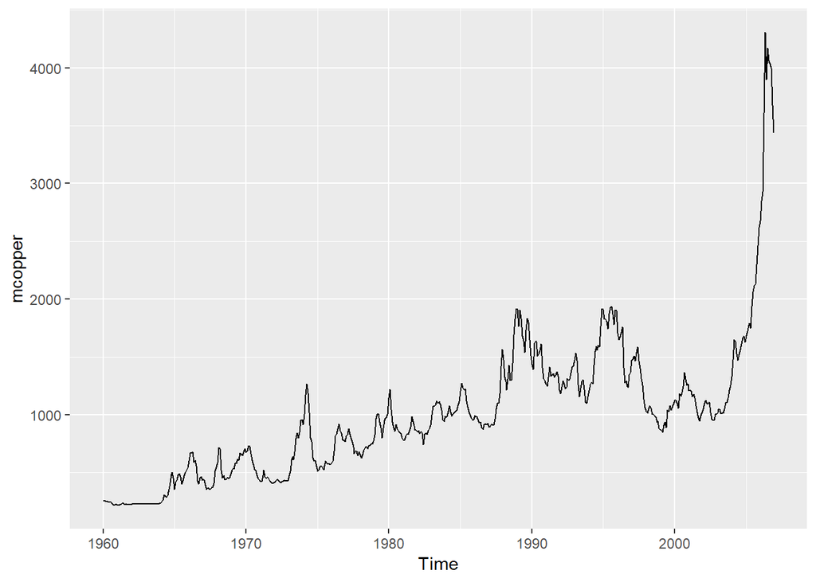

```r
autoplot(mcopper)
```

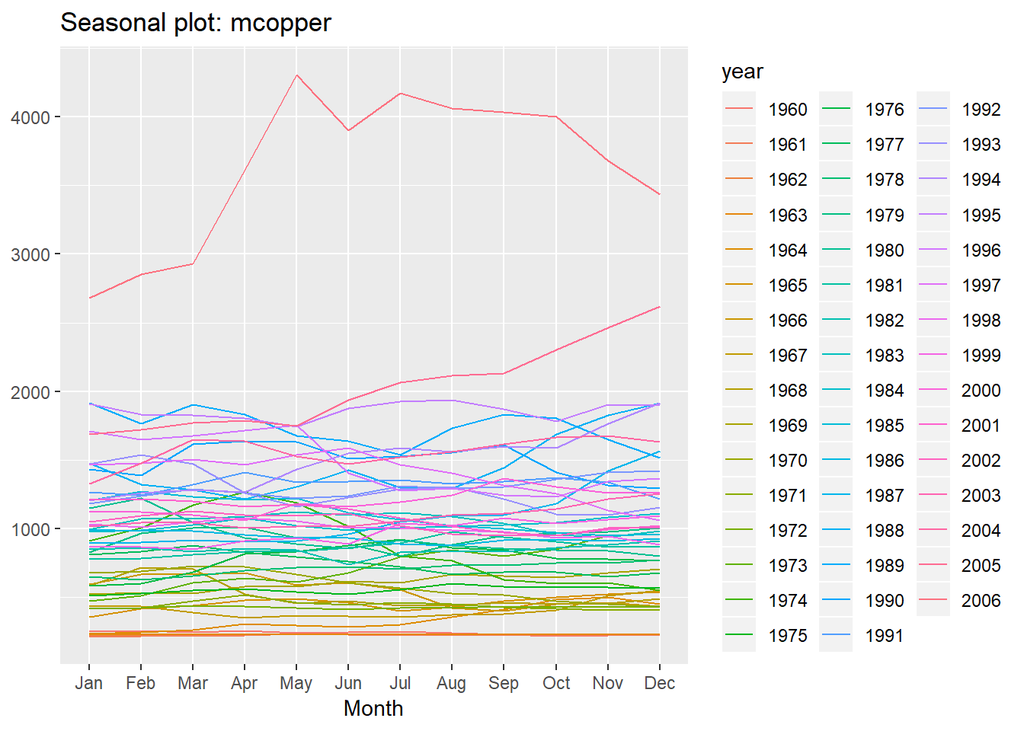

```r
ggseasonplot(mcopper)
```

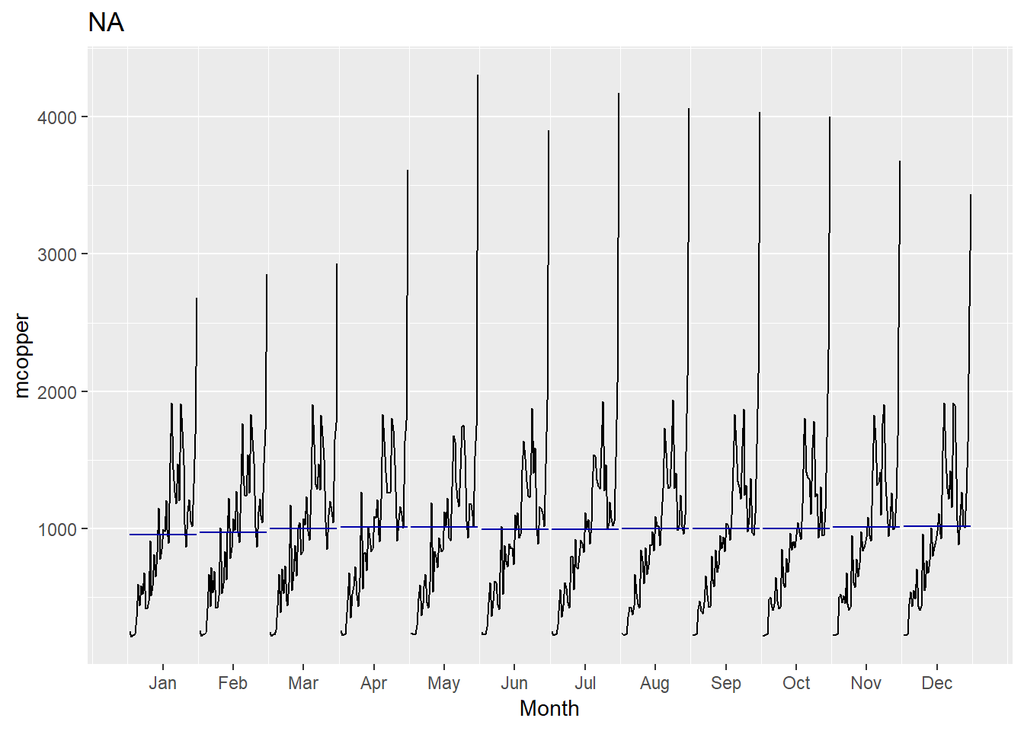

```r
ggsubseriesplot(mcopper)
```

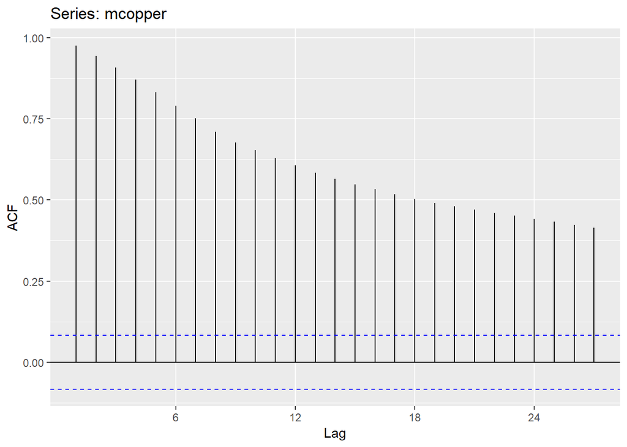

```r
ggAcf(mcopper)
```

```r
Box.test(mcopper, type = "Ljung-Box")
```

```
##
##  Box-Ljung test
##
## data:  mcopper
## X-squared = 539.54, df = 1, p-value < 2.2e-16
```

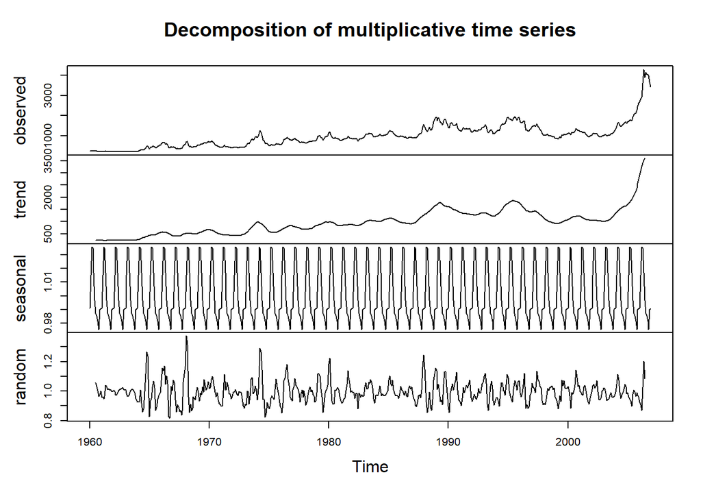

```r
plot(decompose(mcopper, type = "multiplicative"))
```

From the initial autoplot of the dataset we see an increasing trend that exponentially increases. The season plot does not appear to much consistency in the seasons, however it does show the increasing trend. Looking at the subseries plot it appears to be completely consistent in mean. Interestingly, there seems to be seasonality in the decomposition of the data. Also, the ACF plot shows a decreasing trend while the Ljung Box test confirms that this series is not white noise.

Since there is an upward trend, we need to put less emphasis by taking the log. And for the sake of curiousity, a BoxCox transformation is also done on both the log and not log version of the data. The `auto.arima()` function then uses this to calculate the best fitting ARIMA model.

```r
log.mcopper<-log(mcopper)
BoxCox_Mcopper_log <- car::boxCoxVariable(log.mcopper)
BoxCox_Mcopper <- car::boxCoxVariable(mcopper)

BoxCox_lam<-BoxCox(mcopper, BoxCox.lambda(mcopper))
BoxCox_lam_l<-BoxCox(log.mcopper, BoxCox.lambda(log.mcopper))


auto.arima(log.mcopper)
```

```
## Series: log.mcopper
## ARIMA(0,1,1)
##
## Coefficients:
##          ma1
##       0.3756
## s.e.  0.0385
##
## sigma^2 estimated as 0.003634:  log likelihood=782.84
## AIC=-1561.69   AICc=-1561.66   BIC=-1553.02
```

```r
auto.arima(BoxCox_Mcopper)
```

```
## Series: BoxCox_Mcopper
## ARIMA(3,1,1)(0,0,1)[12]
##
## Coefficients:
##           ar1     ar2     ar3     ma1     sma1
##       -0.6611  0.1929  0.2154  0.8315  -0.2819
## s.e.   0.0935  0.0540  0.0456  0.0916   0.0905
##
## sigma^2 estimated as 6149:  log likelihood=-3252.86
## AIC=6517.71   AICc=6517.87   BIC=6543.71
```

```r
auto.arima(BoxCox_Mcopper_log)
```

```
## Series: BoxCox_Mcopper_log
## ARIMA(0,1,1)(1,0,0)[12]
##
## Coefficients:
##          ma1    sar1
##       0.3013  0.0224
## s.e.  0.0420  0.0502
##
## sigma^2 estimated as 2.847e-05:  log likelihood=2149.27
## AIC=-4292.53   AICc=-4292.49   BIC=-4279.53
```

```r
auto.arima(BoxCox_lam)
```

```
## Series: BoxCox_lam
## ARIMA(0,1,1)
##
## Coefficients:
##          ma1
##       0.3720
## s.e.  0.0388
##
## sigma^2 estimated as 0.04997:  log likelihood=45.05
## AIC=-86.1   AICc=-86.08   BIC=-77.43
```

```r
auto.arima(BoxCox_lam_l)
```

```
## Series: BoxCox_lam_l
## ARIMA(0,1,1)
##
## Coefficients:
##          ma1
##       0.3737
## s.e.  0.0387
##
## sigma^2 estimated as 0.1672:  log likelihood=-294.98
## AIC=593.96   AICc=593.98   BIC=602.62
```

From these different models, it seems that the `auto.arima()` model for the BoxCox transformation of the log transformation for `mcopper` works the best with the smallest AICc value. Interstingly, this model has seasonality to it on a monthly basis. Since the other models have extremely high AICc values compared to this model’s value of -4292.49, it makes sense to only focus on it.

Manually picking out the ARIMA model using the log of the data, we have the option of ending up with a different model or the same model. The `ndiffs()` function suggests that one differencing is needed to make the series stationary and `nsdiffs()` suggests zero for seasonal differencing.

```r
ndiffs(BoxCox_Mcopper_log) #confirms that there only needs to be one different in order to make the series stationary.
```

```
## [1] 1
```

```r
nsdiffs(BoxCox_Mcopper_log)#also confirms no SEASONAL differencing
```

```
## [1] 0
```

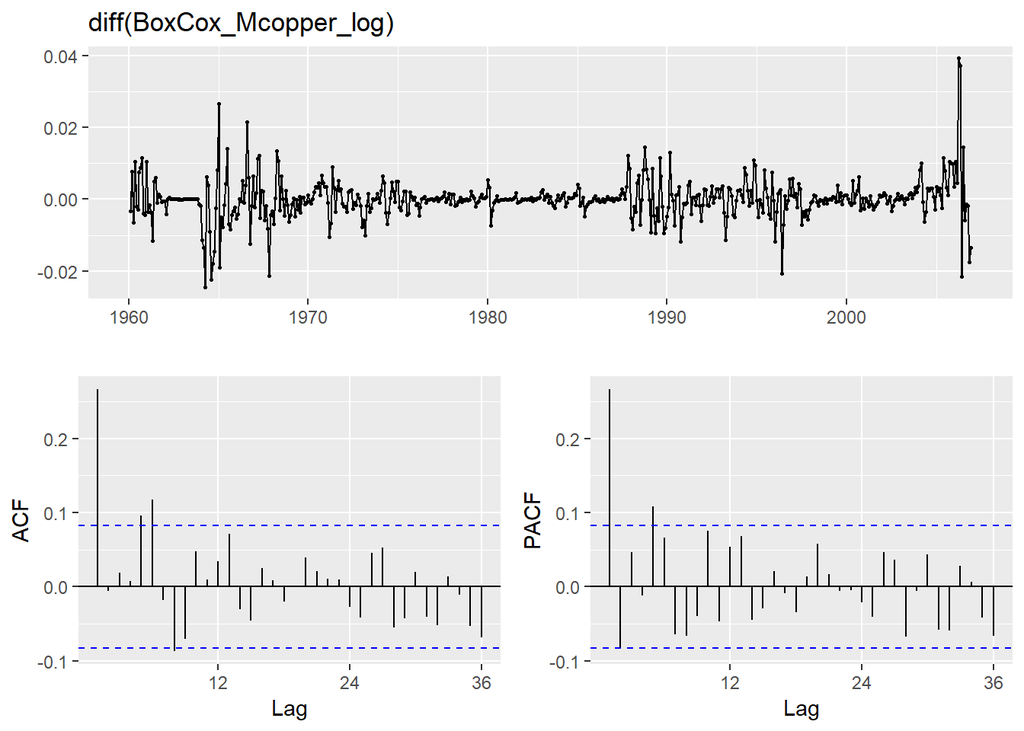

```r
ggtsdisplay(diff(BoxCox_Mcopper_log))
```

Both the ACF and PACF have a sinusoidal pattern. From these graphs, it seems like this differenced data is best fitted with a AR(1) or a MA(1). Seasonally, there is a possibility for a AR(1) or MA(2) assuming yearly seasonality/cyclicality.

Let’s look at both models:

```r
fit <-Arima(BoxCox_Mcopper_log, order = c(1,1,0), seasonal = c(1,0,0))
fit2 <-Arima(BoxCox_Mcopper_log, order = c(0,1,1), seasonal = c(1,0,0))
fit3 <-Arima(BoxCox_Mcopper_log, order = c(1,1,0), seasonal = c(0,0,2))
fit4 <-Arima(BoxCox_Mcopper_log, order = c(0,1,1), seasonal = c(0,0,2))
fit$aicc
```

```
## [1] -4287.521
```

```r
fit2$aicc
```

```
## [1] -4292.488
```

```r
fit3$aicc
```

```
## [1] -4285.934
```

```r
fit4$aicc
```

```
## [1] -4290.727
```

Compared to the `auto.arima()` choice’s AICc value of -4292.49, the other models seem to not do any better. Therefore, the `auto.arima()` model is the best fit.

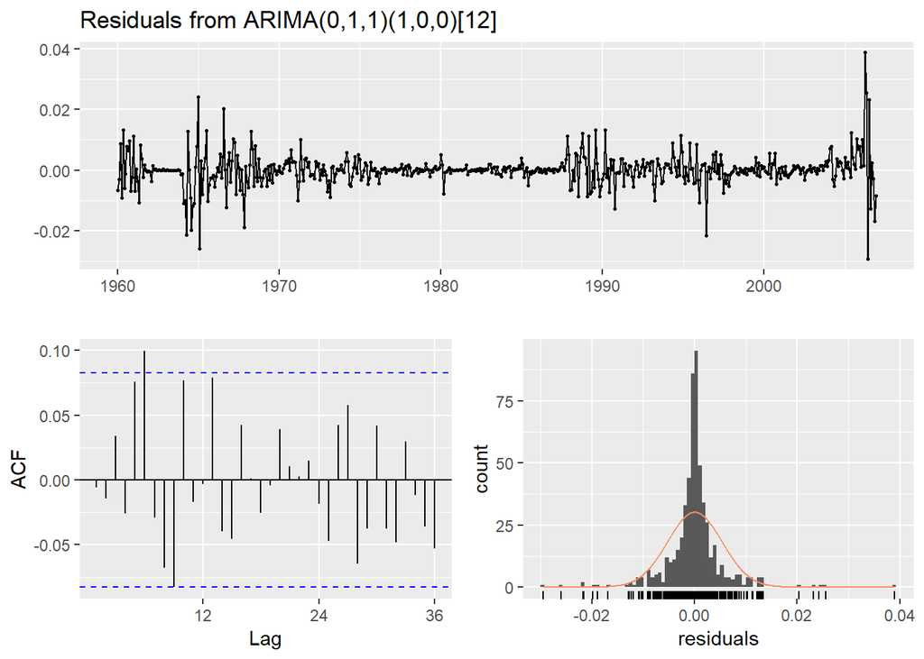

```
##
##  Ljung-Box test
##
## data:  Residuals from ARIMA(0,1,1)(1,0,0)[12]
## Q* = 29.191, df = 22, p-value = 0.1395
##
## Model df: 2.   Total lags used: 24
```

```r
checkresiduals(auto.arima(BoxCox_Mcopper_log))
```

The value of the Ljung-Box test for the auto-picked model is over the threshold to not be considered white noise which is a good thing. It means that this model has captured most of the information in the data!

Now let’s do some forecasting:

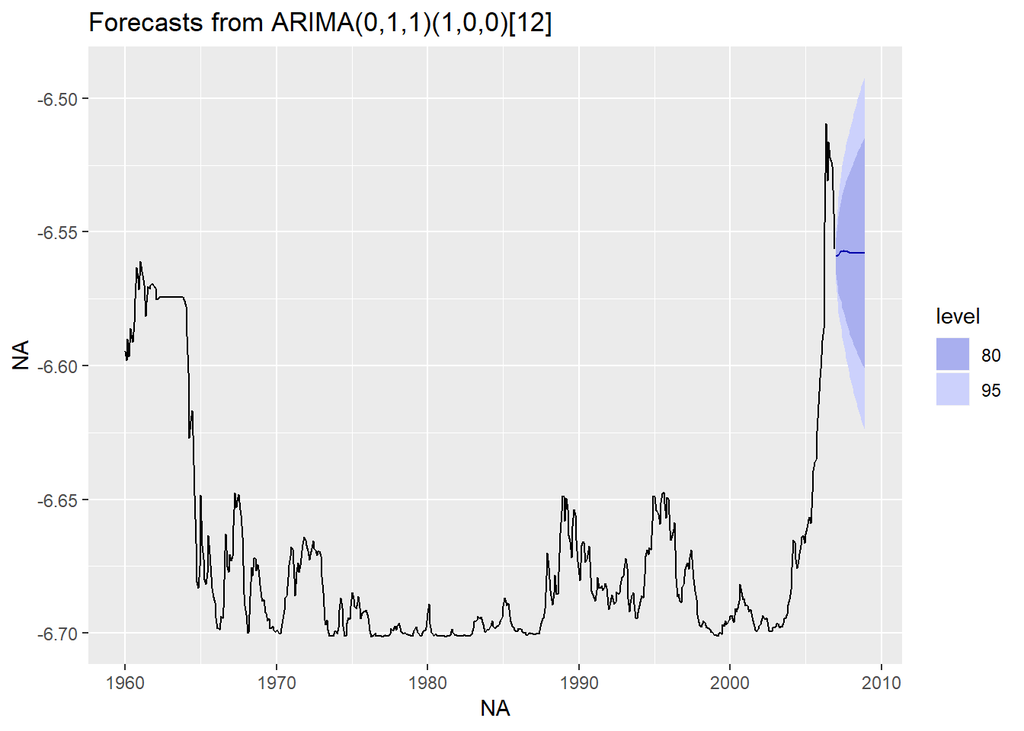

```r
autoplot(forecast(auto.arima(BoxCox_Mcopper_log)))
```

This seems like a fairly small range of forecast both for 80% and 95% confidence.

```r
ets(mcopper)
```

```
## ETS(M,Ad,N)
##
## Call:
##  ets(y = mcopper)
##
##   Smoothing parameters:
##     alpha = 0.9999
##     beta  = 0.2141
##     phi   = 0.8
##
##   Initial states:
##     l = 265.0541
##     b = -3.9142
##
##   sigma:  0.0632
##
##      AIC     AICc      BIC
## 8052.038 8052.189 8078.049
```

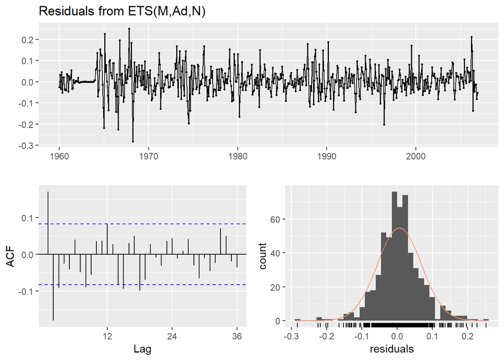

```
##
##  Ljung-Box test
##
## data:  Residuals from ETS(M,Ad,N)
## Q* = 77.585, df = 19, p-value = 4.832e-09
##
## Model df: 5.   Total lags used: 24
```

```r
checkresiduals(ets(mcopper))
```

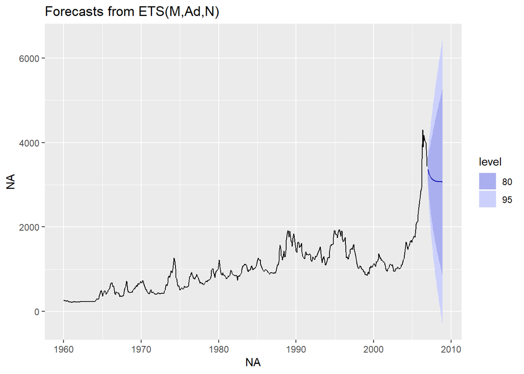

```r
autoplot(forecast(ets(mcopper)))
```

```r
accuracy(ets(mcopper))
```

```
##                    ME     RMSE      MAE       MPE     MAPE      MASE
## Training set 2.691483 78.87699 46.76047 0.1883633 4.503026 0.2103854
##                   ACF1
## Training set 0.1052005
```

```r
accuracy(auto.arima(BoxCox_Mcopper_log))
```

```
##                        ME        RMSE         MAE           MPE       MAPE
## Training set 3.735637e-05 0.005321098 0.003048985 -0.0005899562 0.04584309
##                   MASE        ACF1
## Training set 0.2087992 -0.00602565
```

In short, the seasonal ARIMA model–ARIMA(0,1,1)(1,0,0)[12]–does the best in forecasting when looking at the AICc and RMSE values comparitively to the ETS model.